# ML practice 5: Logistic regression. ROC-curve, AUC

Продолжаем изучать методы классификации. И сегодня мы говорим о регрессии для классификации. А точнее – о логистической регрессии

```r
library(caret)
```

```r
library(ggplot2)
```

### Данные

Датасет, с которым мы работаем сегодня – результаты диагностики диабета.

```r
library(mlbench)
data(PimaIndiansDiabetes2)
library(dplyr)
#Diabetes = na.omit(PimaIndiansDiabetes2)
Diabetes = PimaIndiansDiabetes2
```

## Регрессия для бинарных предсказаний

Разбиение на тестовую и обучающую

```r
set.seed(100) #You shoud put here your own number
test.ind = createDataPartition(Diabetes$diabetes, p = 0.2, list = FALSE)
Diabetes.test = Diabetes[test.ind,]
Diabetes.main = Diabetes[-test.ind,]
```

diabetes – это фактор (neg/pos).

Давайте немного изменим датасет:

- введем новую переменную `db` = 1, если есть диабет, 0, если нет;
- удалим переменную diabetes (иначе предсказания однозначны)

```r
Diabetes.main2 = mutate(Diabetes.main, db = as.numeric(diabetes=="pos"))
Diabetes.main2 = dplyr::select(Diabetes.main2, -diabetes)
```

Построение линейной модели

```r
lm.model <- lm(db~., data = Diabetes.main2)
summary(lm.model)
```

```
##
## Call:
## lm(formula = db ~ ., data = Diabetes.main2)
##
## Residuals:
##      Min       1Q   Median       3Q      Max
## -1.03289 -0.26873 -0.06697  0.28641  0.93604
##
## Coefficients:
##               Estimate Std. Error t value Pr(>|t|)
## (Intercept) -1.076e+00  1.634e-01  -6.584 2.02e-10 ***
## pregnant     1.023e-02  9.695e-03   1.055   0.2924
## glucose      6.362e-03  9.173e-04   6.936 2.45e-11 ***
## pressure     2.260e-04  1.903e-03   0.119   0.9056
## triceps      3.191e-03  2.841e-03   1.123   0.2623
## insulin     -7.373e-05  2.375e-04  -0.310   0.7565
## mass         6.312e-03  4.318e-03   1.462   0.1448
## pedigree     1.171e-01  6.683e-02   1.752   0.0809 .
## age          7.245e-03  3.252e-03   2.228   0.0266 *
## ---
## Signif. codes:  0 '***' 0.001 '**' 0.01 '*' 0.05 '.' 0.1 ' ' 1
##
## Residual standard error: 0.3905 on 303 degrees of freedom
##   (302 observations deleted due to missingness)
## Multiple R-squared:  0.3369, Adjusted R-squared:  0.3194
## F-statistic: 19.24 on 8 and 303 DF,  p-value: < 2.2e-16
```

Посмотрим на соответствие реальных и предсказанных значений

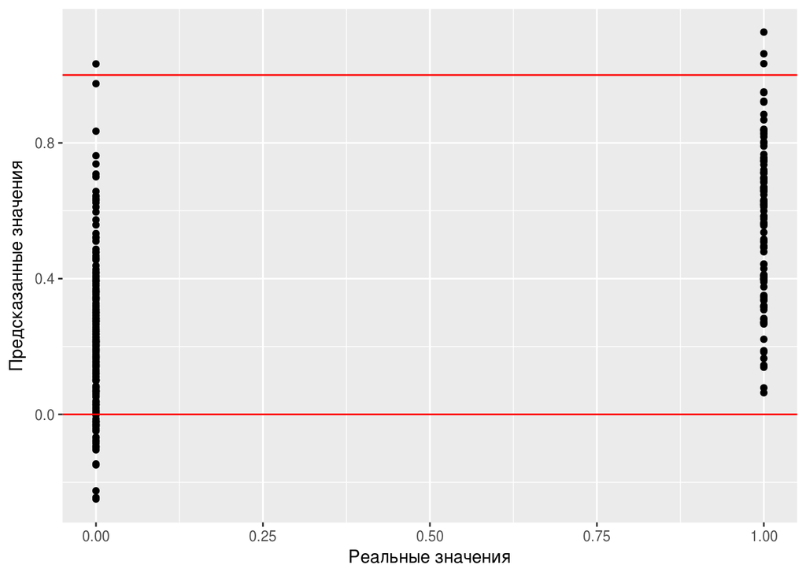

```r
ggplot() + geom_point(aes(x=Diabetes.main2$db, y = predict(lm.model, Diabetes.main2))) +
  geom_hline(yintercept = c(0,1), color = "red") +
  xlab("Реальные значения")+
  ylab("Предсказанные значения")
```

Как делать выводы о наличии или отсутствии диабета? Т.е. если значения от 0 до 1 еще можно было попробовать обосновать как некую “вероятность”, то что делать со значениями, попадающими сильно за эти пределы

Но аппарат регрессии все равно использовать хочется. Выход был найден следующий: давайте предсказывать не само значение, а вероятность попадания в класс = 1. Раз это вероятность, то она должна быть в промежутке от 0 до 1. Преобразуем немного наше значение с помощью сигмоидной функции – какое бы значение мы ни использовали в Input, Output будет от 0 до 1. Формула для сигмоидной функции $f(x)=e^x/(e^x+1)$.

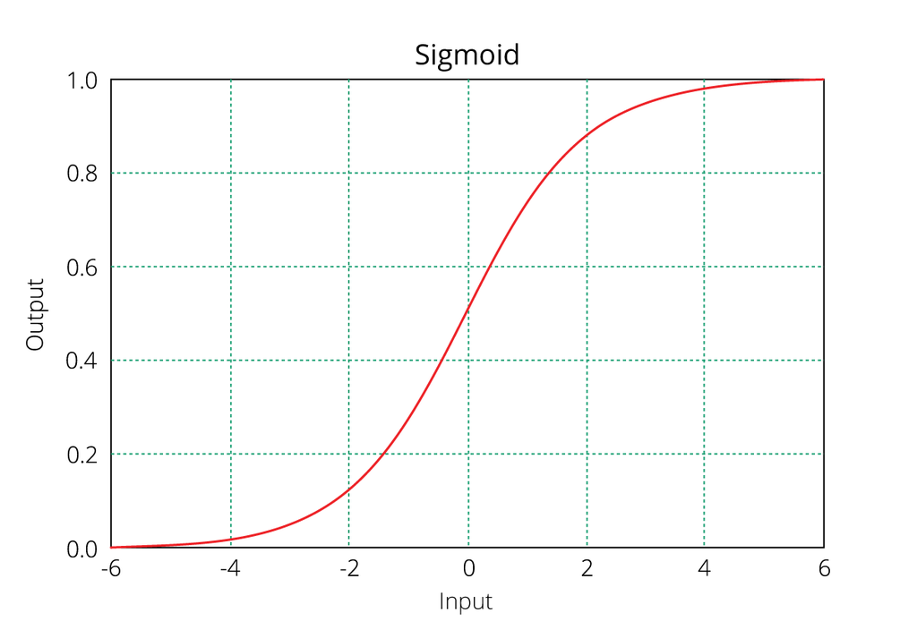

В контексте регрессии получаем (для любителей формул)

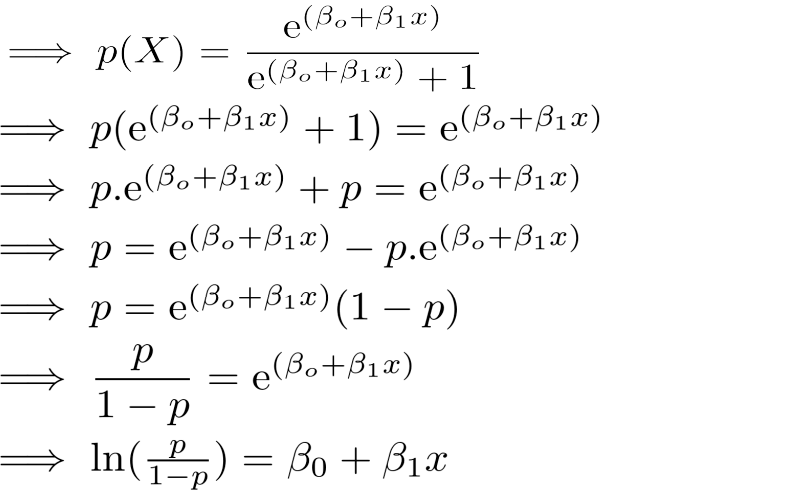

А отсюда получаем и интепретацию коэффициентов регрессии: увеличение значения на 1 приводит к увеличению шансов в $e^{коэффициент}$ раз.

## Построение модели

Теперь к тому, как получить логистическую регрессию в R (работает и с факторами!)

```r
log.model = glm(diabetes~., data = Diabetes.main, family = binomial(link = 'logit'))
summary(log.model)
```

```
##
## Call:
## glm(formula = diabetes ~ ., family = binomial(link = "logit"),
##     data = Diabetes.main)
##
## Deviance Residuals:
##     Min       1Q   Median       3Q      Max
## -2.6318  -0.6826  -0.3755   0.6718   2.3108
##
## Coefficients:
##               Estimate Std. Error z value Pr(>|z|)
## (Intercept) -9.7485451  1.3508900  -7.216 5.34e-13 ***
## pregnant     0.0586374  0.0616340   0.951   0.3414
## glucose      0.0379745  0.0064620   5.877 4.19e-09 ***
## pressure     0.0006979  0.0127467   0.055   0.9563
## triceps      0.0217398  0.0190979   1.138   0.2550
## insulin     -0.0005520  0.0015422  -0.358   0.7204
## mass         0.0478385  0.0289523   1.652   0.0985 .
## pedigree     0.8332352  0.4768572   1.747   0.0806 .
## age          0.0413609  0.0212046   1.951   0.0511 .
## ---
## Signif. codes:  0 '***' 0.001 '**' 0.01 '*' 0.05 '.' 0.1 ' ' 1
##
## (Dispersion parameter for binomial family taken to be 1)
##
##     Null deviance: 398.56  on 311  degrees of freedom
## Residual deviance: 279.41  on 303  degrees of freedom
##   (302 observations deleted due to missingness)
## AIC: 297.41
##
## Number of Fisher Scoring iterations: 5
```

```r
log.model2 = glm(db~., data = Diabetes.main2, family = binomial(link = 'logit'))
summary(log.model2)
```

```
##
## Call:
## glm(formula = db ~ ., family = binomial(link = "logit"), data = Diabetes.main2)
##
## Deviance Residuals:
##     Min       1Q   Median       3Q      Max
## -2.6318  -0.6826  -0.3755   0.6718   2.3108
##
## Coefficients:
##               Estimate Std. Error z value Pr(>|z|)
## (Intercept) -9.7485451  1.3508900  -7.216 5.34e-13 ***
## pregnant     0.0586374  0.0616340   0.951   0.3414
## glucose      0.0379745  0.0064620   5.877 4.19e-09 ***
## pressure     0.0006979  0.0127467   0.055   0.9563
## triceps      0.0217398  0.0190979   1.138   0.2550
## insulin     -0.0005520  0.0015422  -0.358   0.7204
## mass         0.0478385  0.0289523   1.652   0.0985 .
## pedigree     0.8332352  0.4768572   1.747   0.0806 .
## age          0.0413609  0.0212046   1.951   0.0511 .
## ---
## Signif. codes:  0 '***' 0.001 '**' 0.01 '*' 0.05 '.' 0.1 ' ' 1
##
## (Dispersion parameter for binomial family taken to be 1)
##
##     Null deviance: 398.56  on 311  degrees of freedom
## Residual deviance: 279.41  on 303  degrees of freedom
##   (302 observations deleted due to missingness)
## AIC: 297.41
##
## Number of Fisher Scoring iterations: 5
```

## Еще раз про метрики

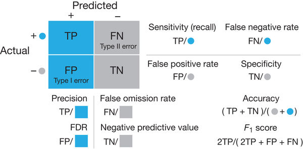

Посмотрим на предсказание. Напомню – предсказываем вероятность. Как по этим значениям отнести к тому или иному классу?

```r
pred = predict(log.model, newdata = Diabetes.test, type = "response")
head(pred)
```

```
##          7          9         12         16         17         31
## 0.04055824 0.91372240         NA         NA 0.40568761         NA
```

**Обратите внимание**: по умолчанию выдается не вероятность, а значение функции. Которая, правда, легко преобразуется в вероятность подстановкой в сигмоидную функцию

```r
predLink = predict(log.model, newdata = Diabetes.test)
head(predLink)
```

```
##          7          9         12         16         17         31
## -3.1636127  2.3599569         NA         NA -0.3818217         NA
```

```r
head(exp(predLink)/(exp(predLink)+1))
```

```
##          7          9         12         16         17         31
## 0.04055824 0.91372240         NA         NA 0.40568761         NA
```

Значение классов можем определить, задав границу разделения

```r
pred0.5 <- ifelse(pred > 0.5,"pos","neg")
confusionMatrix(pred0.5, Diabetes.test$diabetes)
```

```
## Confusion Matrix and Statistics
##
##           Reference
## Prediction neg pos
##        neg  49  12
##        pos   6  13
##
##                Accuracy : 0.775
##                  95% CI : (0.6679, 0.8609)
##     No Information Rate : 0.6875
##     P-Value [Acc > NIR] : 0.0554
##
##                   Kappa : 0.4397
##  Mcnemar's Test P-Value : 0.2386
##
##             Sensitivity : 0.8909
##             Specificity : 0.5200
##          Pos Pred Value : 0.8033
##          Neg Pred Value : 0.6842
##              Prevalence : 0.6875
##          Detection Rate : 0.6125
##    Detection Prevalence : 0.7625
##       Balanced Accuracy : 0.7055
##
##        'Positive' Class : neg
##
```

А если поменять границу?

```r
pred0.7 <- ifelse(pred > 0.7,"pos","neg")
confusionMatrix(pred0.7, Diabetes.test$diabetes)
```

```
## Confusion Matrix and Statistics
##
##           Reference
## Prediction neg pos
##        neg  53  14
##        pos   2  11
##
##                Accuracy : 0.8
##                  95% CI : (0.6956, 0.8811)
##     No Information Rate : 0.6875
##     P-Value [Acc > NIR] : 0.01733
##
##                   Kappa : 0.4644
##  Mcnemar's Test P-Value : 0.00596
##
##             Sensitivity : 0.9636
##             Specificity : 0.4400
##          Pos Pred Value : 0.7910
##          Neg Pred Value : 0.8462
##              Prevalence : 0.6875
##          Detection Rate : 0.6625
##    Detection Prevalence : 0.8375
##       Balanced Accuracy : 0.7018
##
##        'Positive' Class : neg
##
```

Как выбрать? Более того, если у нас несколько подобных моделей, то как узнать, какая модель лучше?

## ROC & AUC

Метрики оценки качества в этом случае

- ROC-кривая (Receiver Operating Characteristic) – график, показывающий соотношение между долей объектов от общего количества носителей признака, верно классифицированных как несущих признак, (true positive rate, TPR, sensitivity, чувствительность алгоритма классификации) и долей объектов от общего количества объектов, не несущих признака, ошибочно классифицированных как несущих признак (англ. false positive rate, FPR, 1-FPR = specificity, специфичность алгоритма классификации) при разных значениях границы, разделяющей классы
- AUC (Area Under ROC Curve) – площадь под этой кривой

```r
library(pROC)
```

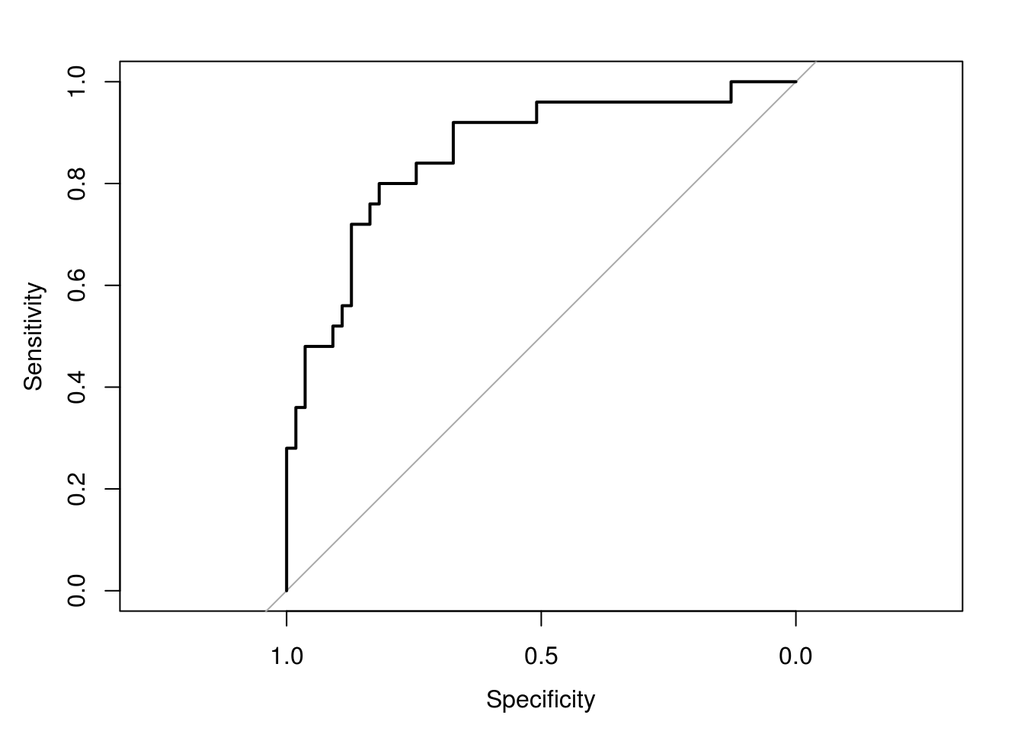

```r
ROCfull = roc(response = Diabetes.test$diabetes, predictor = pred)
plot(ROCfull)
```

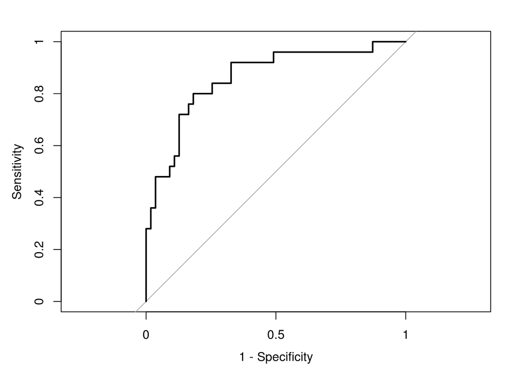

```r
plot(ROCfull, legacy.axes=T)
```

```r
auc(ROCfull)
```

```
## Area under the curve: 0.8611
```

Можно использовать не весь объект, а отдельно specificity и sensitivity и построить ROC с помощью, например, ggplot2

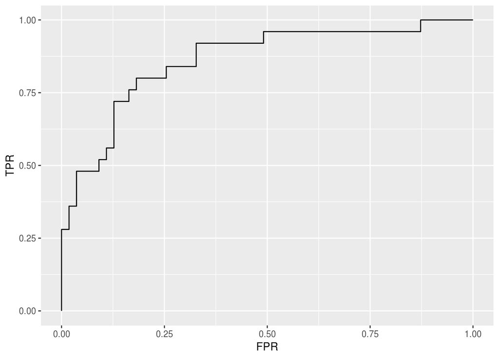

```r
ggplot() + geom_path(aes(y=ROCfull$sensitivities, x=1-ROCfull$specificities))+
  xlab("FPR") + ylab("TPR")
```

Построим еще одну модель

```r
log.modelSmall = glm(diabetes~age, data = Diabetes.main, family = binomial(link = 'logit'))
summary(log.modelSmall)
```

```
##
## Call:
## glm(formula = diabetes ~ age, family = binomial(link = "logit"),
##     data = Diabetes.main)
##
## Deviance Residuals:
##     Min       1Q   Median       3Q      Max
## -1.7027  -0.8433  -0.7315   1.2586   1.7238
##
## Coefficients:
##              Estimate Std. Error z value Pr(>|z|)
## (Intercept) -2.222066   0.273248  -8.132 4.22e-16 ***
## age          0.047281   0.007575   6.242 4.32e-10 ***
## ---
## Signif. codes:  0 '***' 0.001 '**' 0.01 '*' 0.05 '.' 0.1 ' ' 1
##
## (Dispersion parameter for binomial family taken to be 1)
##
##     Null deviance: 793.94  on 613  degrees of freedom
## Residual deviance: 752.47  on 612  degrees of freedom
## AIC: 756.47
##
## Number of Fisher Scoring iterations: 4
```

```r
predSmall = predict(log.modelSmall, newdata = Diabetes.test, type = "response")

ROCsmall = roc(response = Diabetes.test$diabetes, predictor = predSmall)
auc(ROCsmall)
```

```
## Area under the curve: 0.6582
```

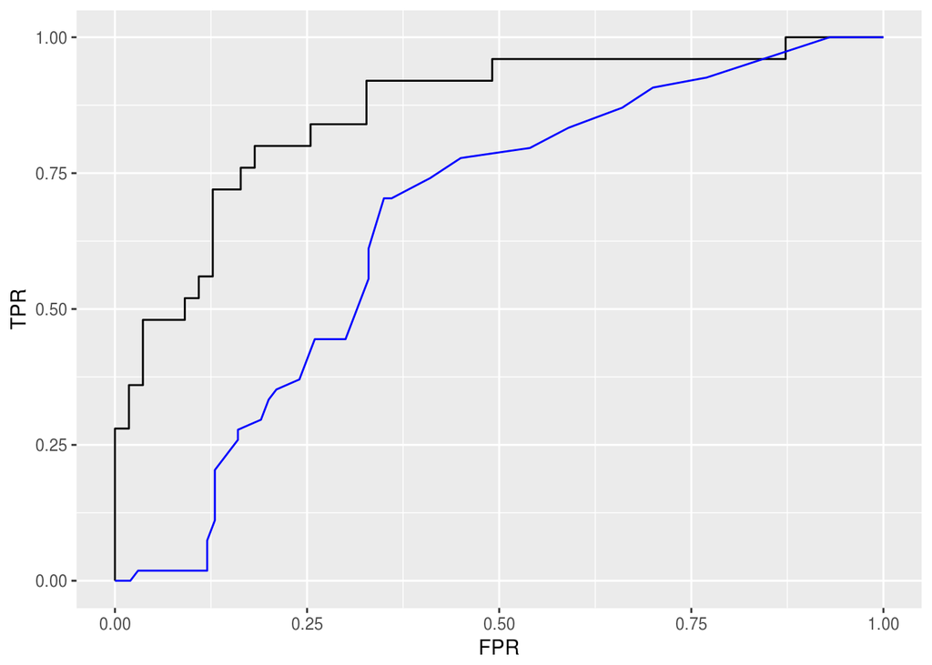

```r
ggplot() + geom_path(aes(y=ROCfull$sensitivities, x=1-ROCfull$specificities)) +
  geom_path(aes(y=ROCsmall$sensitivities, x=1-ROCsmall$specificities), color = "blue") +
  xlab("FPR") + ylab("TPR")
```

Какая модель лучше?

**Ваша очередь:**

Уже рассмотренные данные про продажи детских автомобильных кресел. Задача: предсказать уровень продаж. Т.к. задача классификации предполагает, что целевая переменная (в нашем случае – продажи Sales), должна быть категориальной, то изменим немного наши данные – разделим их на высокие и низкие.

```r
library(ISLR)
library(dplyr)
carseats <- ISLR::Carseats
сarseats <- carseats %>%
  mutate(High = ifelse(Sales <= 8, "No", "Yes")) %>%
  dplyr::select(-Sales)
```